# Introduction to Rotation Matrices

## Rotation Matrix

```matlab
% Let's review our rotation matrices

% Given a PSI rotation angle, the corresponding rotation matrix is given

psi = 10;

psi_in_radians = deg2rad(psi);

Rpsi = [ cos(psi_in_radians),  sin(psi_in_radians),    0;
        -sin(psi_in_radians),  cos(psi_in_radians),    0;
                           0,                    0,    1];
disp('Rotation around Psi = 10');
```

Rotation around Psi = 10

```matlab
disp(Rpsi);
```

0.9848 0.1736 0 -0.1736 0.9848 0 0 0 1.0000

```matlab
% We can do the same for the other angles theta and phi

theta = 10;

theta_in_radians = deg2rad(theta);

Rthe = [cos(theta_in_radians),  0,  -sin(theta_in_radians);
                            0,  1,                       0;
        sin(theta_in_radians),  0,   cos(theta_in_radians)];

disp('Rotation around Theta = 10');
```

Rotation around Theta = 10

```matlab
disp(Rthe);
```

0.9848 0 -0.1736 0 1.0000 0 0.1736 0 0.9848

```matlab
phi = 10;

phi_in_radians = deg2rad(phi);

Rphi = [ 1,                    0,                    0;
         0,  cos(phi_in_radians),  sin(phi_in_radians);
         0, -sin(phi_in_radians),  cos(phi_in_radians)];

disp('Rotation around Phi = 10');
```

Rotation around Phi = 10

```matlab
disp(Rphi);
```

1.0000 0 0 0 0.9848 0.1736 0 -0.1736 0.9848

```matlab
% Now we can rotate a point by psi, theta and phi.
```

```matlab
% Moving between the BODY and WORLD frames

p = [1;0;0];
% We set the point as a 3 row, 1 column matrix - each row corresponding to
% x, y and z coordinates.


% Lets do a rotation for p - let's assume that p is in the WORLD frame and
% we're going to move it into the BODY frame

new_point = Rphi*Rthe*Rpsi*p;

% Remember that the correct order is to rotate around psi first, then
% theta, then phi.  In Matlab, we would write that with the first rotation,
% closest to point p.

disp('Starting at point p');
```

Starting at point p

```matlab
disp(p);
```

1 0 0

```matlab
disp('Rotated by Psi, Theta, Phi');
```

Rotated by Psi, Theta, Phi

```matlab
disp(new_point);
```

0.9698 -0.1413 0.1986

```matlab
% While this is an accurate calculation, this probably doesn't mean
% anything to you.  Let's relate this to something actually useful.

% When would we move something from the WORLD frame to the BODY frame?
```

## Tower Example

```matlab
% Let's do an example

% A tower is at 87 ft North and 30 ft West of our aircraft. Lets assume
% that the tower is 50 ft tall. Our airplane is taking off from the ground
% heading (psi) at -25 degrees and pitching up by 10 degrees.  If the plane
% only goes forward, will the plane crash into the tower?

% We'll start by putting the coordinates of the tower (WORLD FRAME) into an
% array.
tower = [87;-30;-50];

% Next we'll calculate the rotation matrix. The angles represent the
% orientation of the aircraft.

psi = -25;
theta = 10;
phi = 0;

psi_in_radians = deg2rad(psi);
Rpsi = [ cos(psi_in_radians),  sin(psi_in_radians),    0;
        -sin(psi_in_radians),  cos(psi_in_radians),    0;
                           0,                    0,    1];
theta_in_radians = deg2rad(theta);
Rthe = [cos(theta_in_radians),  0,  -sin(theta_in_radians);
                            0,  1,                       0;
        sin(theta_in_radians),  0,   cos(theta_in_radians)];
phi_in_radians = deg2rad(phi);
Rphi = [ 1,                    0,                    0;
         0,  cos(phi_in_radians),  sin(phi_in_radians);
         0, -sin(phi_in_radians),  cos(phi_in_radians)];

tower_body = Rphi*Rthe*Rpsi*tower;

disp('Tower - relative to the airplane');
```

Tower - relative to the airplane

```matlab
disp(tower_body);
```

98.8192 9.5786 -33.3468

```matlab
disp(['The tower is ',num2str(tower_body(1)),'ft in front of the airplane']);
```

The tower is 98.8192ft in front of the airplane

```matlab
disp(['The tower is ',num2str(tower_body(2)),'ft to the right of the airplane']);
```

The tower is 9.5786ft to the right of the airplane

```matlab
disp(['The distance between the airplane and top of the tower is ',num2str(tower_body(3)),'ft']);
```

The distance between the airplane and top of the tower is -33.3468ft

```matlab
% Will the airplane hit the tower?

% If it will hit the tower, how can we fix it?
```

```matlab
% Let's draw this out

% We can create a new polygon for the tower and draw it
tower_size = 5;
tower_points = [tower(1)-tower_size,tower(2)-tower_size,0;
                tower(1)+tower_size,tower(2)-tower_size,0;
                tower(1)-tower_size,tower(2)+tower_size,0;
                tower(1)+tower_size,tower(2)+tower_size,0;
                tower(1)-tower_size,tower(2)-tower_size,tower(3);
                tower(1)+tower_size,tower(2)-tower_size,tower(3);
                tower(1)-tower_size,tower(2)+tower_size,tower(3);
                tower(1)+tower_size,tower(2)+tower_size,tower(3)];
tower_faces = [1,2,4,3;
               1,2,6,5;
               2,4,8,6;
               4,3,7,8;
               3,1,5,7;
               5,6,8,7];

% Now let's try with a different number

psi =-20
```

psi = -20

```matlab
theta = 34
```

theta = 34

```matlab
phi = 0;

psi_in_radians = deg2rad(psi);
Rpsi = [ cos(psi_in_radians),  sin(psi_in_radians),    0;
        -sin(psi_in_radians),  cos(psi_in_radians),    0;
                           0,                    0,    1];
theta_in_radians = deg2rad(theta);
Rthe = [cos(theta_in_radians),  0,  -sin(theta_in_radians);
                            0,  1,                       0;
        sin(theta_in_radians),  0,   cos(theta_in_radians)];
phi_in_radians = deg2rad(phi);
Rphi = [ 1,                    0,                    0;
         0,  cos(phi_in_radians),  sin(phi_in_radians);
         0, -sin(phi_in_radians),  cos(phi_in_radians)];

tower_body = Rphi*Rthe*Rpsi*tower;

disp('Tower - relative to the airplane');
```

Tower - relative to the airplane

```matlab
disp(tower_body);
```

104.2426 1.5650 10.0016

```matlab
disp(['The tower is ',num2str(tower_body(1)),'ft in front of the airplane']);
```

The tower is 104.2426ft in front of the airplane

```matlab
disp(['The tower is ',num2str(tower_body(2)),'ft to the right of the airplane']);
```

The tower is 1.565ft to the right of the airplane

```matlab
disp(['The distance between the airplane and top of the tower is ',num2str(tower_body(3)),'ft']);
```

The distance between the airplane and top of the tower is 10.0016ft

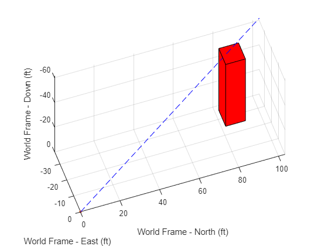

```matlab
figure;
patch('Faces',tower_faces,'Vertices',tower_points,'FaceColor','red'); hold on;
grid on;

view([-19.2 53.9])

% Now we'll draw the airplane's trajectory

east_trajectory = 110*cos(psi_in_radians);
north_trajectory = 110*sin(psi_in_radians);
up_trajectory = 110*sin(-theta_in_radians);

plot3([0,east_trajectory],[0,north_trajectory],[0,up_trajectory],'--b');
xlabel('World Frame - North (ft)');
ylabel('World Frame - East (ft)');
zlabel('World Frame - Down (ft)');
set(gca, 'ZDir','reverse')
set(gca, 'YDir','reverse')


plot3(0,0,0,'.','MarkerSize',10);
axis equal;
```

```matlab
% Now it's clear whether we'll hit the tower or not.  And we can tell that
% our rotation matrix was correct here.
```

## Using Functions

```matlab
% It can get tiresome to keep having to copy-paste or rerun the rotation
% matrix equations every time.  It's easier if we rewrite it as a
% programming function.


% To write a function, click on the arrow below NEW in Matlab, then select
% either 'Function' or 'Live Function'  Use 'Function' for regular *.m
% files and use 'Live Function' for *.mlx files.

% In the new file, write in your function
```

function out = function_name(function_input1,function_input2)

out = function_input1 + function_input2;

end

```matlab
% Now we can use it in our script

testing = function_name(1,2);

disp(testing);
```

3

```matlab
% Lets make a function to generate a rotation matrix for Phi
```

function R = rotate_phi(angle)

angle = deg2rad(angle);

R = [1,0,0;

0,cos(angle),sin(angle);

0,-sin(angle),cos(angle)];

end

```matlab
% Now we can do

Rphi = rotate_phi(50);

disp('Rotation Matrix - 50 degrees Phi');
```

Rotation Matrix - 50 degrees Phi

```matlab
disp(Rphi);
```

1.0000 0 0 0 0.6428 0.7660 0 -0.7660 0.6428

```matlab
% We can repeat that for the other rotations as well.

Rpsi = rotate_psi(10);
Rthe = rotate_theta(-30);
```

```matlab
% And now we can calculate our WORLD to BODY rotation matrix

R_world_2_body = Rphi*Rthe*Rpsi;

disp('Rotation Matrix - WORLD to BODY');
```

Rotation Matrix - WORLD to BODY

```matlab
disp(R_world_2_body);
```

0.8529 0.1504 0.5000 -0.4888 0.5665 0.6634 -0.1835 -0.8102 0.5567

```matlab
% And if we want to go the other way, we take the transpose:

R_body_2_world = R_world_2_body';
disp('Rotation Matrix - BODY to WORLD');
```

Rotation Matrix - BODY to WORLD

```matlab
disp(R_body_2_world);
```

0.8529 -0.4888 -0.1835 0.1504 0.5665 -0.8102 0.5000 0.6634 0.5567

```matlab
% We can compact this a bit more

% We can create a function that calls other functions
```

function R = Rotate_World_2_Body(psi,theta,phi)

Rpsi = rotate_psi(psi);

Rthe = rotate_theta(theta);

Rphi = rotate_phi(phi);

R = Rphi*Rthe*Rpsi;

end

```matlab
% Now it's even simpler

psi = -110
```

psi = -110

```matlab
theta = -7
```

theta = -7

```matlab
phi = -73
```

phi = -73

```matlab
R_world_2_body = Rotate_World_2_Body(psi,theta,phi);

disp('Rotation Matrix - WORLD to BODY');
```

Rotation Matrix - WORLD to BODY

```matlab
disp(R_world_2_body);
```

-0.3395 -0.9327 0.1219 0.2349 -0.2095 -0.9492 0.9108 -0.2936 0.2902

```matlab
disp('');
```

```matlab
% Lets have some fun with the Airplane Model

% We can delete all the other things in our workspace now.
%clear;
load Lab_Airplane.mat

% Lets take a closer look at the workspace. Our airplane variable
% is a 36 x 3 matrix. However, in order for us to use a rotation matrix
% on it, we'll need to switch some things up.

% First, we need to transpose it to a 3 x 36

airplane_pts = airplane';

% The original dimensions were in meters, but let's write this out in ft.
% Multiply everything by the scale factor
airplane_scale = 3.28;
airplane_pts = airplane_pts*airplane_scale;

% Now let's input the rotation amounts

psi = 60
```

psi =

60

```matlab
theta = 6
```

theta =

6

```matlab
phi = -4
```

phi =

-4

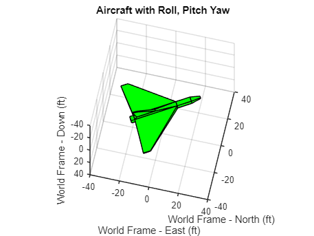

```matlab
R_world_2_body = Rotate_World_2_Body(psi,theta,phi);
%Transpose
R_body_2_world = R_world_2_body';

airplane_pts = R_body_2_world*airplane_pts;

% Next, we'll need to transpose the airplane poinnts back to a 36x3
airplane_pts = airplane_pts';


figure; hold on;
patch('Faces',f,'Vertices',airplane_pts,'FaceColor','green');
grid on; axis equal; title('Aircraft with Roll, Pitch Yaw'); xlabel('World Frame - North (ft)');
ylabel('World Frame - East (ft)'); zlabel('World Frame - Down (ft)'); set(gca, 'ZDir','reverse')
set(gca, 'YDir','reverse'); hold off; axis([-40 40 -40 40, -40 40]); view([-77.0 66.0])
```

```matlab
disp('Airplane Orientation');
```

Airplane Orientation

```matlab
disp(R_body_2_world);
```

0.497260947684137 -0.867561577928826 -0.00827395974847686 0.861281226008774 0.492467368852296 0.125182028824109 -0.104528463267653 -0.0693743404822147 0.992099290015652